# Practical Machine Learning Project

Justin Wen

September 20, 2015

## Introduction

In this project, we will be analyzing data gathered from sensors attached to participants instructed to perform bicep curls with a dumbbell either correctly (Class A) or in an incorrect fashion (Classes B-E). The data will be used to build a model and predict the manner in which the exercise was done.

## Loading the Data

```r
download.file("https://d396qusza40orc.cloudfront.net/predmachlearn/pml-training.csv", "pml-training.csv")
data <- read.csv("pml-training.csv")

library(caret)
library(rpart)
library(randomForest)
library(rattle)
```

## Splitting Data into Training and Testing

After loading the data, we can set a seed and split the dataset into training and test sets.

```r
set.seed(208)
inTrain <- createDataPartition(y=data$classe, p=0.7, list=FALSE)
training <- data[inTrain, ]
testing <- data[-inTrain, ]
```

## Cleaning the Data

After looking over the different columns in the dataset, it is apparent that there are a few columns that are not important for predicting the manner in which the exercise is being done. These columns are “X”, “user_name”, the 3 timestamp columns and “new_window”. The reasoning for this is that X is just an index for the row number, the user that is doing the exercise, when they are doing it and whether it is a new window or not are not relevant. Therefore, we can create a new training and testing set without those variables.

```r
training <- training[,c(-1,-2,-3,-4,-5,-6)]
testing <- testing[,c(-1,-2,-3,-4,-5,-6)]
```

Next we can determine if any variables have zero or near zero variability and remove them (no variables have zero variability so we just remove all near zero variability columns):

```r
nsv <- nearZeroVar(training, saveMetrics=TRUE)
logi <- !nsv$nzv
training <- training[,logi]
testing <- testing[,logi]
```

Of the remaining columns, by looking at `View(training)`, we can see there still exists quite a few that are comprised largely of NA’s. We will remove these variables:

```r
## Initialize an empty index variable
index <- NULL

## Loop over all columns and add the column index to the index variable if the first value is NA
for (i in 1:ncol(training)) {
     if (is.na(training[,i][1])) {
          index <- c(index, i)
     }
}

## Subset the datasets to remove all columns that have a first value of NA
training <- training[,-index]
testing <- testing[,-index]
```

Finally, we will convert all columns besides classe to numeric:

```r
## Convert all columns besides classe to numeric
for (i in 1:ncol(training)) {
     if (class(training[,i]) == "numeric") {next}
     else if(i == ncol(training)) {next}
     else {
          training[,i] <- as.numeric(training[,i])
          testing[,i] <- as.numeric(testing[,i])
     }
}
```

## Model

### Decision Tree

We will first build a model using the “rpart” method for tree-based models:

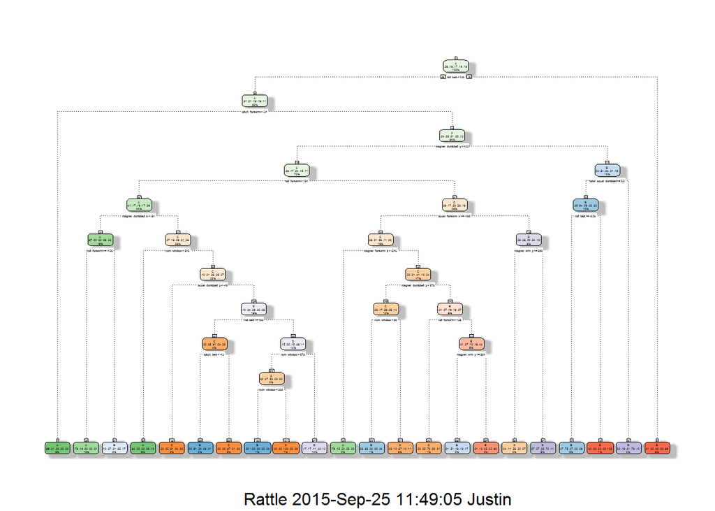

```r
modelFit1 <- rpart(classe ~ ., data=training, method = "class")
fancyRpartPlot(modelFit1)
```

```r
predictions1 <- predict(modelFit1, testing, type = "class")
confusionMatrix(predictions1, testing$classe)
```

```
## Confusion Matrix and Statistics
##
##           Reference
## Prediction    A    B    C    D    E
##          A 1452  156   11   49   38
##          B   46  662   55   88   98
##          C   22   97  843   74   66
##          D  144  186  101  704  155
##          E   10   38   16   49  725
##
## Overall Statistics
##
##                Accuracy : 0.7453
##                  95% CI : (0.7339, 0.7564)
##     No Information Rate : 0.2845
##     P-Value [Acc > NIR] : < 2.2e-16
##
##                   Kappa : 0.6782
##  Mcnemar's Test P-Value : < 2.2e-16
##
## Statistics by Class:
##
##                      Class: A Class: B Class: C Class: D Class: E
## Sensitivity            0.8674   0.5812   0.8216   0.7303   0.6701
## Specificity            0.9397   0.9395   0.9467   0.8809   0.9765
## Pos Pred Value         0.8511   0.6976   0.7650   0.5457   0.8652
## Neg Pred Value         0.9469   0.9034   0.9617   0.9434   0.9293
## Prevalence             0.2845   0.1935   0.1743   0.1638   0.1839
## Detection Rate         0.2467   0.1125   0.1432   0.1196   0.1232
## Detection Prevalence   0.2899   0.1613   0.1873   0.2192   0.1424
## Balanced Accuracy      0.9035   0.7604   0.8842   0.8056   0.8233
```

Upon evaluating the confusion matrix against the test set, we can see that this method is not particularly accurate.

### Random Forest

Next, we will build a model using the random forest method:

```r
modelFit2 <- randomForest(classe ~ ., data=training)
predictions2 <- predict(modelFit2, testing)
confusionMatrix(predictions2, testing$classe)
```

```
## Confusion Matrix and Statistics
##
##           Reference
## Prediction    A    B    C    D    E
##          A 1674    1    0    0    0
##          B    0 1138    8    0    0
##          C    0    0 1018    3    0
##          D    0    0    0  961    1
##          E    0    0    0    0 1081
##
## Overall Statistics
##
##                Accuracy : 0.9978
##                  95% CI : (0.9962, 0.9988)
##     No Information Rate : 0.2845
##     P-Value [Acc > NIR] : < 2.2e-16
##
##                   Kappa : 0.9972
##  Mcnemar's Test P-Value : NA
##
## Statistics by Class:
##
##                      Class: A Class: B Class: C Class: D Class: E
## Sensitivity            1.0000   0.9991   0.9922   0.9969   0.9991
## Specificity            0.9998   0.9983   0.9994   0.9998   1.0000
## Pos Pred Value         0.9994   0.9930   0.9971   0.9990   1.0000
## Neg Pred Value         1.0000   0.9998   0.9984   0.9994   0.9998
## Prevalence             0.2845   0.1935   0.1743   0.1638   0.1839
## Detection Rate         0.2845   0.1934   0.1730   0.1633   0.1837
## Detection Prevalence   0.2846   0.1947   0.1735   0.1635   0.1837
## Balanced Accuracy      0.9999   0.9987   0.9958   0.9983   0.9995
```

Upon evaluating the confusion matrix, we can see that the random forest method was much more accurate in its predictions.

## Test Cases for Submission

Finally, we will predict the exercise for the test cases needed for submission.

```r
download.file("https://d396qusza40orc.cloudfront.net/predmachlearn/pml-testing.csv", "pml-testing.csv")
test <- read.csv("pml-testing.csv")
predictions3 <- predict(modelFit2, test)
predictions3
```

```
##  1  2  3  4  5  6  7  8  9 10 11 12 13 14 15 16 17 18 19 20
##  B  A  B  A  A  E  D  B  A  A  B  C  B  A  E  E  A  B  B  B
## Levels: A B C D E
```

## Conclusions

Two models were developed and tested against the test dataset: one using a decision tree and another using random forests. The random forest model proved to be much better at predicting the correct Class of the exercise from the given data.